# EDA_Code

Rachel & Santiago

2022-10-21

#Introduction #We have been asked by Budweiser to run an analysis on their beers and breweries data that they have collected and answer a few questions. #Below we have completed our Exploratory Data Analysis over the datasets provided. #If there are any questions, please reach ask or reach out to our emails.

#QUESTION 1 #Discuss the numbers of breweries per state.

```r
library(dplyr)
```

```r
library(tidyr)
library(stringi)
library(ggplot2)
library(twitteR)
library(httr)
library(jsonlite)
library(tidyverse)
library(GGally)
library(mvtnorm)
library(class)
library(caret)
library(e1071)

#Create a heatmap to show how many breweries are in each state.
Breweries = read.csv("/Users/santigtz/Desktop/SMU D.S./6306 - Doing Data Science/Unit 8 and 9 Case Study 1/Breweries.csv", header = TRUE)

lookup = data.frame(abb=state.abb, State = state.name)

#Pull only the State and City information out of the dataset to create less clutter.
#Change the name of State to "abb" to create a foreign key.
brews = Breweries[,c(3:4)]
colnames(brews)[2] = "abb"
brews$abb = str_trim(brews$abb, "left")

#Merge the lookup table and our state tables to create a master copy. This will
#allow us to create our heatmap later.
#Change name to State to be able to count the total number of breweries per State.
brews2 = merge(brews,lookup,by = "abb")

#Use the count function to create a sum total of number of breweries per State.
#Print the overall dataset brewery map to see if it added correctly.
brewerymaps = count(brews2,State)
brewerymaps
```

```
##             State  n
## 1         Alabama  3
## 2          Alaska  7
## 3         Arizona 11
## 4        Arkansas  2
## 5      California 39
## 6        Colorado 47
## 7     Connecticut  8
## 8        Delaware  2
## 9         Florida 15
## 10        Georgia  7
## 11         Hawaii  4
## 12          Idaho  5
## 13       Illinois 18
## 14        Indiana 22
```

[output cut: 36 more lines]

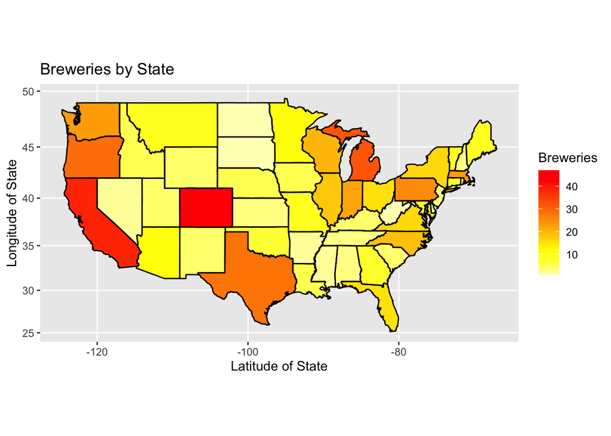

```r
#Change brewery to Breweries name
colnames(brewerymaps)[2] = "Breweries"

#Create a region column that is all lowercase to match all states
brewerymaps$region <-tolower(brewerymaps$State)

#Remove the first column so we only have state and Region
brewerymaps = brewerymaps[-1]

#Create a state map based on States.
states<- map_data("state")

#Merge dataframes brewerymaps and states in order to create
# a heat map for breweries by state
map.df<- merge(states, brewerymaps, by = "region", all.x=T)
map.df<- map.df[order(map.df$order),]

p<-ggplot(map.df,aes(x=long,y=lat,group=group)) +
  geom_polygon(aes(fill=Breweries))+
  geom_path() + xlab("Latitude of State") + ylab("Longitude of State") +
  scale_fill_gradientn(colours = rev(heat.colors(10)), na.value ="grey90") +
  ggtitle("Breweries by State") + coord_map()
p
```

## QUESTION 2

#Merge datasets by “Brew_ID” and print the head and tail of the combined breweries and beers dataset.

```r
Beers = read.csv("/Users/santigtz/Desktop/SMU D.S./6306 - Doing Data Science/Unit 8 and 9 Case Study 1/Beers.csv", header = TRUE)
colnames(Beers)[colnames(Beers)=="Brewery_id"] <- "Brew_ID"

Oktoberfest = merge(Breweries, Beers, by="Brew_ID")
head(Oktoberfest, n=6)
```

```
##   Brew_ID             Name.x        City State        Name.y Beer_ID   ABV IBU
## 1       1 NorthGate Brewing  Minneapolis    MN       Pumpion    2689 0.060  38
## 2       1 NorthGate Brewing  Minneapolis    MN    Stronghold    2688 0.060  25
## 3       1 NorthGate Brewing  Minneapolis    MN   Parapet ESB    2687 0.056  47
## 4       1 NorthGate Brewing  Minneapolis    MN  Get Together    2692 0.045  50
## 5       1 NorthGate Brewing  Minneapolis    MN Maggie's Leap    2691 0.049  26
## 6       1 NorthGate Brewing  Minneapolis    MN    Wall's End    2690 0.048  19
##                                 Style Ounces
## 1                         Pumpkin Ale     16
## 2                     American Porter     16
## 3 Extra Special / Strong Bitter (ESB)     16
## 4                        American IPA     16
## 5                  Milk / Sweet Stout     16
## 6                   English Brown Ale     16
```

```r
tail(Oktoberfest, n=6)
```

```
##      Brew_ID                        Name.x          City State
## 2405     556         Ukiah Brewing Company         Ukiah    CA
## 2406     557       Butternuts Beer and Ale Garrattsville    NY
## 2407     557       Butternuts Beer and Ale Garrattsville    NY
## 2408     557       Butternuts Beer and Ale Garrattsville    NY
## 2409     557       Butternuts Beer and Ale Garrattsville    NY
## 2410     558 Sleeping Lady Brewing Company     Anchorage    AK
##                         Name.y Beer_ID   ABV IBU                   Style Ounces
## 2405             Pilsner Ukiah      98 0.055  NA         German Pilsener     12
## 2406         Porkslap Pale Ale      49 0.043  NA American Pale Ale (APA)     12
## 2407           Snapperhead IPA      51 0.068  NA            American IPA     12
## 2408         Moo Thunder Stout      50 0.049  NA      Milk / Sweet Stout     12
## 2409  Heinnieweisse Weissebier      52 0.049  NA              Hefeweizen     12
## 2410 Urban Wilderness Pale Ale      30 0.049  NA        English Pale Ale     12
```

## QUESTION 3

#How many NA values in ABV and IBU? #There are 62 missing NA values for ABV and 1005 missing values #for IBU. The ABV values won’t have a huge effect on the data but #almost half (42%) of IBU is missing. Removing these will be neccessary #but will also make our data less accurate.

```r
colSums(is.na(Oktoberfest))
```

```
## Brew_ID  Name.x    City   State  Name.y Beer_ID     ABV     IBU   Style  Ounces
##       0       0       0       0       0       0      62    1005       0       0
```

## QUESTION 4

#Compute the median ABV by state and plot a bar chart to comapare # We removed all NA values from each column to do this analysis. #Kentucky has the highest median ABV, followed by DC, Kentucky, West Viriginia and New Mexico. There weren’t many more states that were above the average of ABV.

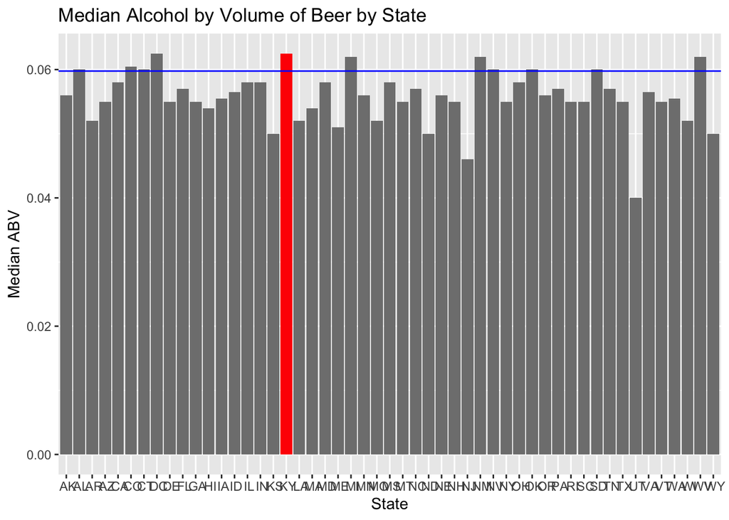

```r
median_ABV_plot = Oktoberfest %>%
  filter(!is.na(ABV)) %>%
  group_by(State) %>%
  summarize(median=median(ABV),count=n())%>%
  ggplot(aes(x=State, y = median, fill = factor(if_else(State == " KY","Highest", "All Others")))) +  geom_bar(stat="identity", show.legend = FALSE) + scale_fill_manual(name = "State", values=c("grey50","red")) + ggtitle("Median Alcohol by Volume of Beer by State") + ylab("Median ABV") + geom_hline(yintercept = mean(Oktoberfest$ABV, na.rm = TRUE), color="blue")
median_ABV_plot
```

#The median IBU has Maine with the highest one. There are a lot more states that are above the average of the IBU than ABV.

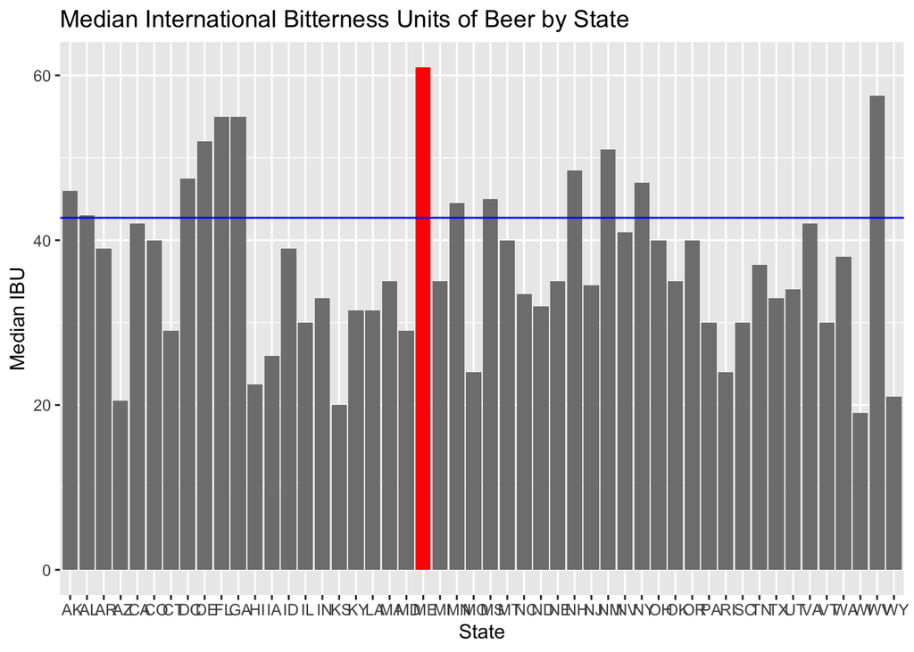

```r
median_IBU_plot = Oktoberfest %>%
  filter(!is.na(IBU)) %>%
  group_by(State) %>%
  summarize(median=median(IBU),count=n())%>%
  ggplot(aes(x=State, y = median, fill = factor(if_else(State == " ME","Highest", "All Others")))) +  geom_bar(stat="identity", show.legend = FALSE) + scale_fill_manual(name = "State", values=c("grey50","red")) + ggtitle("Median International Bitterness Units of Beer by State") + ylab("Median IBU") + geom_hline(yintercept = mean(Oktoberfest$IBU, na.rm = TRUE), color="blue")
median_IBU_plot
```

## QUESTION 5

#Which state has the beer with the maximum ABV? Colorado at 12.8% #Which state has the most bitter beer (IBU)? Oregon with 138 IBU

```r
Oktoberfest[which.max(Oktoberfest$ABV),]
```

```
##     Brew_ID                  Name.x    City State
## 384      52 Upslope Brewing Company Boulder    CO
##                                                   Name.y Beer_ID   ABV IBU
## 384 Lee Hill Series Vol. 5 - Belgian Style Quadrupel Ale    2565 0.128  NA
##                Style Ounces
## 384 Quadrupel (Quad)   19.2
```

```r
Oktoberfest[which.max(Oktoberfest$IBU),]
```

```
##      Brew_ID                  Name.x    City State                    Name.y
## 1857     375 Astoria Brewing Company Astoria    OR Bitter Bitch Imperial IPA
##      Beer_ID   ABV IBU                          Style Ounces
## 1857     980 0.082 138 American Double / Imperial IPA     12
```

## QUESTION 6

#There are 62 missing values or 2.5% of the data data missing ABV values. #The ABV has a median of 5.6% and a mean of 5.9% which is pretty average for beer. The beer with the highest was 12.8% in Colorado and the lowest ABV was at 0.1% (which is extremely low). It is interesting that Colorado had the highest ABV because altitude makes you feel the effects of beer more. The data is right skewed because most of the values are centered around 5% but we have a lot of higher perecentages and not a lot of lower ones.

```r
summary(Oktoberfest$ABV)
```

```
##    Min. 1st Qu.  Median    Mean 3rd Qu.    Max.    NA's
## 0.00100 0.05000 0.05600 0.05977 0.06700 0.12800      62
```

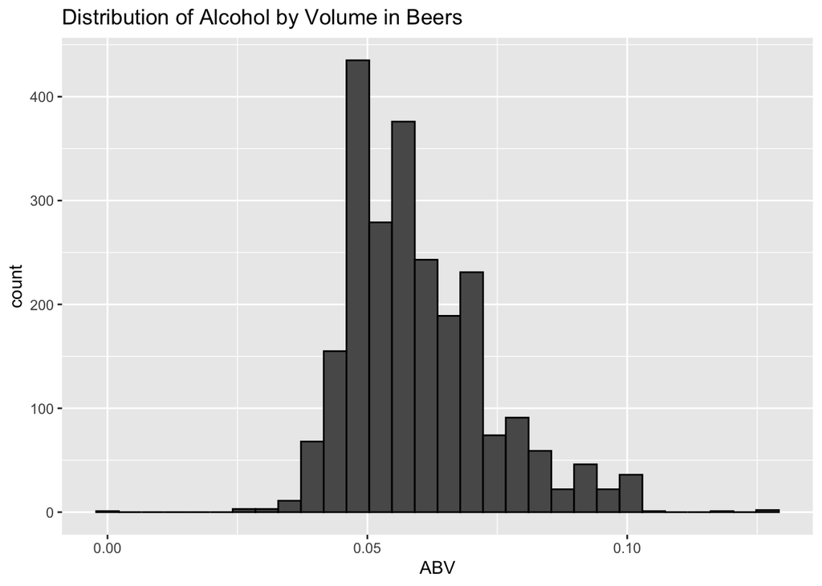

```r
Oktoberfest %>%
ggplot(aes(x= ABV)) + geom_histogram(color = "Black") +
  ggtitle("Distribution of Alcohol by Volume in Beers")
```

## QUESTION 7

#Is there a relationship between ABV and IBU? #Yes, there is a correlation between these values. There is a positive correlation shown in the coefficient being 0.671. This is a moderate correlation. An increase in IBU is associated with an increase (but not caused by) an increase in ABV (and vice versa).

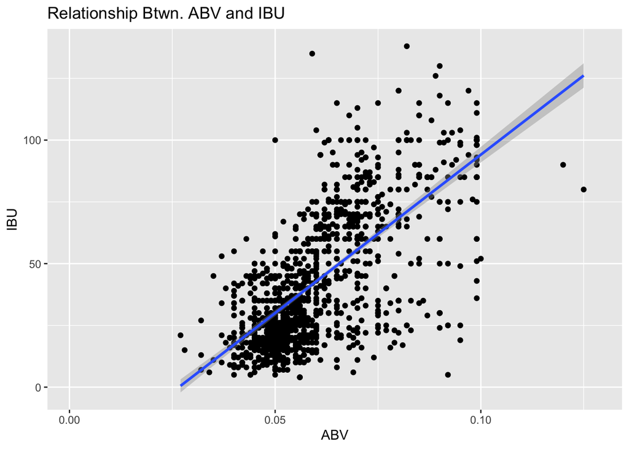

```r
ggplot(data = Oktoberfest, mapping = aes(x = Oktoberfest$ABV, y = Oktoberfest$IBU))+
  geom_point() +
  geom_smooth(method = lm) + xlab("ABV") + ylab("IBU") + ggtitle("Relationship Btwn. ABV and IBU")
```

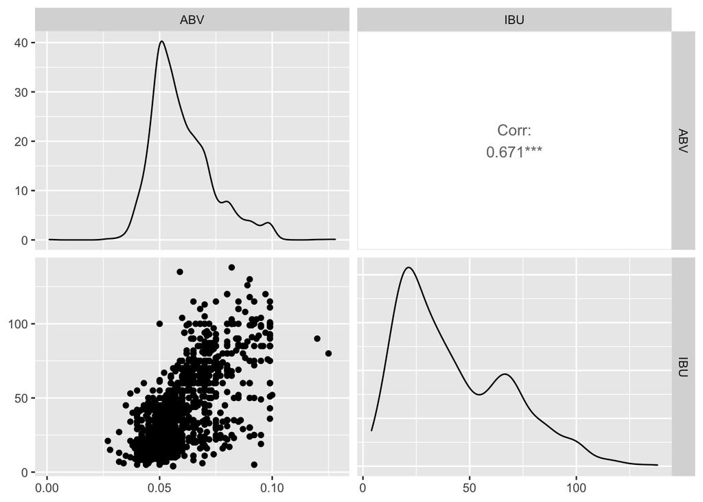

```r
Beer_Comparison = Oktoberfest %>% select(ABV, IBU)
ggpairs(Beer_Comparison)
```

## QUESTION 8

```r
Breweries = read.csv("/Users/santigtz/Desktop/SMU D.S./6306 - Doing Data Science/Unit 8 and 9 Case Study 1/Breweries.csv", header = TRUE)
Breweries$State = as.factor(Breweries$State)
dplyr::count(Breweries, State)
```

```
##    State  n
## 1     AK  7
## 2     AL  3
## 3     AR  2
## 4     AZ 11
## 5     CA 39
## 6     CO 47
## 7     CT  8
## 8     DC  1
## 9     DE  2
## 10    FL 15
## 11    GA  7
## 12    HI  4
## 13    IA  5
## 14    ID  5
```

[output cut: 37 more lines]

```r
Beers = read.csv("/Users/santigtz/Desktop/SMU D.S./6306 - Doing Data Science/Unit 8 and 9 Case Study 1/Beers.csv", header = TRUE)
colnames(Beers)[colnames(Beers)=="Brewery_id"] <- "Brew_ID"
Oktoberfest = merge(Breweries, Beers, by="Brew_ID")

Oktoberfest1 = Oktoberfest %>%
  mutate(Style = if_else(str_detect(Oktoberfest$Style, "IPA"), "IPA", if_else(str_detect(Oktoberfest$Style, "Ale"), "Ale", "Other"))) %>%
  filter(!is.na(ABV)) %>%
  filter(!is.na(IBU)) %>%
  filter(Style == "IPA" | Style == "Ale") %>%
  select(ABV, IBU, Style)
Oktoberfest1$Style = as.factor(Oktoberfest1$Style)
levels(Oktoberfest1$Style)
```

```
## [1] "Ale" "IPA"
```

```r
set.seed(1)
splitPerc = .7
iterations = 100
numks = 60
masterAcc = matrix(nrow = iterations, ncol = numks)

for(j in 1:iterations)
{
  accs = data.frame(accuracy = numeric(60), k = numeric(60))
  trainIndices = sample(1:dim(Oktoberfest1)[1],round(splitPerc * dim(Oktoberfest1)[1]))
  train = Oktoberfest1[trainIndices,]
  test = Oktoberfest1[-trainIndices,]
  for(i in 1:numks)
  {
    classifications = knn(train[,c(1,2)],test[,c(1,2)],train$Style, prob = TRUE, k = i)
    table(test$Style,classifications)
    CM = confusionMatrix(table(test$Style,classifications))
    masterAcc[j,i] = CM$overall[1]
  }

}
CM
```

```
## Confusion Matrix and Statistics
##
##      classifications
##       Ale IPA
##   Ale 152  21
##   IPA  23  87
##
##                Accuracy : 0.8445
##                  95% CI : (0.797, 0.8847)
##     No Information Rate : 0.6184
##     P-Value [Acc > NIR] : <2e-16
##
##                   Kappa : 0.6717
##
##  Mcnemar's Test P-Value : 0.8802
##
##             Sensitivity : 0.8686
##             Specificity : 0.8056
##          Pos Pred Value : 0.8786
##          Neg Pred Value : 0.7909
##              Prevalence : 0.6184
##          Detection Rate : 0.5371
##    Detection Prevalence : 0.6113
##       Balanced Accuracy : 0.8371
##
##        'Positive' Class : Ale
##
```

```r
MeanAcc = colMeans(masterAcc)
which.max(MeanAcc)
```

```
## [1] 5
```

```r
max(MeanAcc)
```

```
## [1] 0.8571731
```

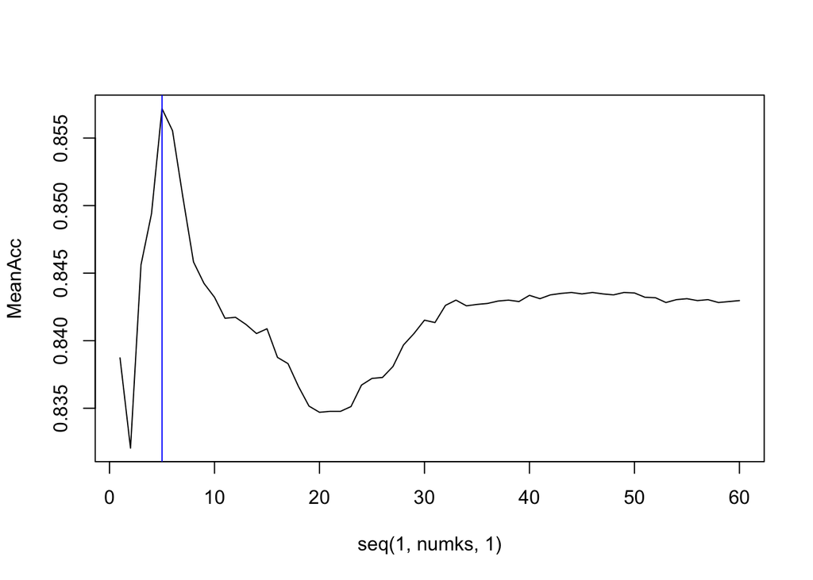

```
## integer(0)
```

```r
plot(seq(1,numks,1),MeanAcc, type = "l") + abline(v = which.max(MeanAcc), col="blue")
```

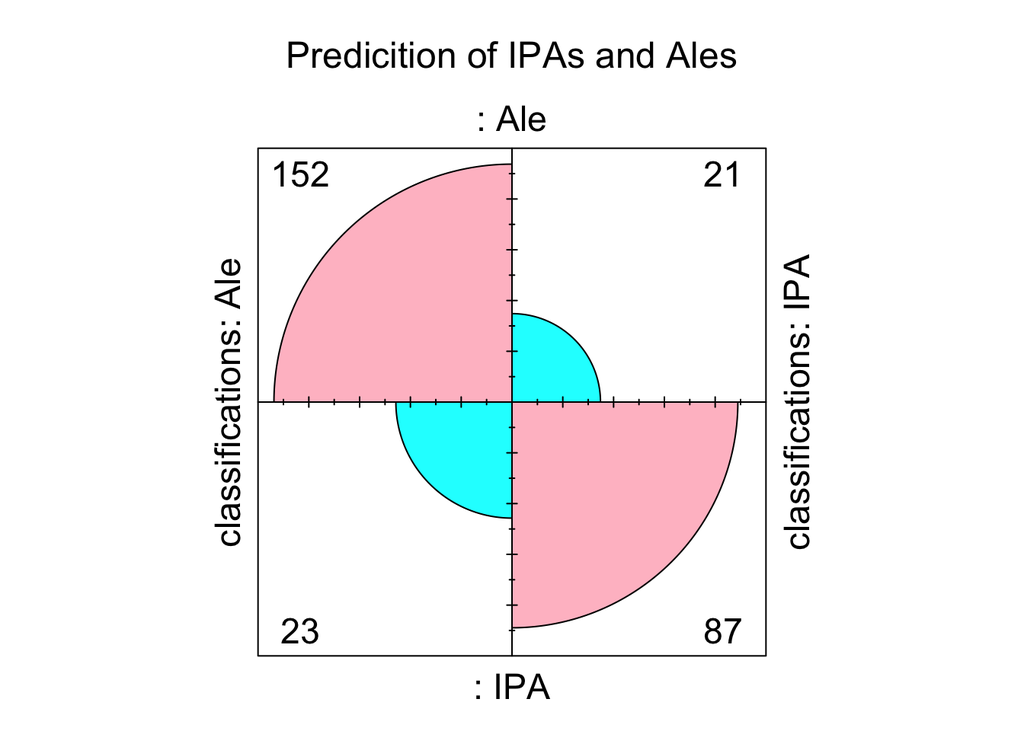

```r
fourfoldplot(CM$table,color = c("cyan", "pink"),
             conf.level = 0, margin = 1, main = "Predicition of IPAs and Ales")
```

# Sensitivity for each class is the percent of that class that was classified correctly. # Specificity for Class X is the percentage of elements not in that class that were correctly classified as not being in that class (class x).

## ABV & IBU to determine type of Ale

```r
Breweries = read.csv("/Users/santigtz/Desktop/SMU D.S./6306 - Doing Data Science/Unit 8 and 9 Case Study 1/Breweries.csv", header = TRUE)
Breweries$State = as.factor(Breweries$State)
dplyr::count(Breweries, State)
```

```
##    State  n
## 1     AK  7
## 2     AL  3
## 3     AR  2
## 4     AZ 11
## 5     CA 39
## 6     CO 47
## 7     CT  8
## 8     DC  1
## 9     DE  2
## 10    FL 15
## 11    GA  7
## 12    HI  4
## 13    IA  5
## 14    ID  5
```

[output cut: 37 more lines]

```r
Beers = read.csv("/Users/santigtz/Desktop/SMU D.S./6306 - Doing Data Science/Unit 8 and 9 Case Study 1/Beers.csv", header = TRUE)
colnames(Beers)[colnames(Beers)=="Brewery_id"] <- "Brew_ID"
Oktoberfest = merge(Breweries, Beers, by="Brew_ID")

## Check for number of different American Ale types
Oktoberfest2 = Oktoberfest %>%
  filter(!is.na(ABV)) %>%
  filter(!is.na(IBU)) %>%
  filter(!is.na(IBU)) %>%
  select(ABV, IBU, Style)
Oktoberfest2$Style = as.factor(Oktoberfest2$Style)

Ale_Freq = table(Oktoberfest2$Style)
Ale_Freq
```

```
##
##                                                        Abbey Single Ale
##                                   2                                   2
##                             Altbier              American Adjunct Lager
##                                   8                                  11
##            American Amber / Red Ale          American Amber / Red Lager
##                                  77                                  16
##                 American Barleywine                  American Black Ale
##                                   2                                  20
##                 American Blonde Ale                  American Brown Ale
##                                  61                                  38
##             American Dark Wheat Ale      American Double / Imperial IPA
##                                   5                                  75
##  American Double / Imperial Pilsner    American Double / Imperial Stout
##                                   1                                   3
##           American India Pale Lager                        American IPA
##                                   3                                 301
##             American Pale Ale (APA)                 American Pale Lager
##                                 153                                  16
##             American Pale Wheat Ale                    American Pilsner
##                                  61                                  14
##                     American Porter                      American Stout
##                                  39                                  16
##                 American Strong Ale                  American White IPA
##                                  12                                   6
##                   American Wild Ale                       Baltic Porter
##                                   2                                   3
##                    Belgian Dark Ale                         Belgian IPA
##                                   3                                   3
##                    Belgian Pale Ale             Belgian Strong Dark Ale
##                                   8                                   1
##             Belgian Strong Pale Ale                  Berliner Weissbier
##                                   2                                   5
##                      Bière de Garde                                Bock
##                                   2                                   3
##      California Common / Steam Beer                          Chile Beer
##                                   2                                   2
##                           Cream Ale                      Czech Pilsener
##                                  18                                  16
##                          Doppelbock           Dortmunder / Export Lager
```

[output cut: 38 more lines]

```
##                                   1                                   3
##                          Roggenbier              Russian Imperial Stout
##                                   1                                   8
##                            Rye Beer              Saison / Farmhouse Ale
##                                   9                                  23
##                         Schwarzbier              Scotch Ale / Wee Heavy
##                                   4                                  13
##                        Scottish Ale                         Smoked Beer
##                                  11                                   1
##                              Tripel                        Vienna Lager
##                                   4                                  14
##                           Wheat Ale                       Winter Warmer
##                                   1                                   8
##                             Witbier
##                                  24
```

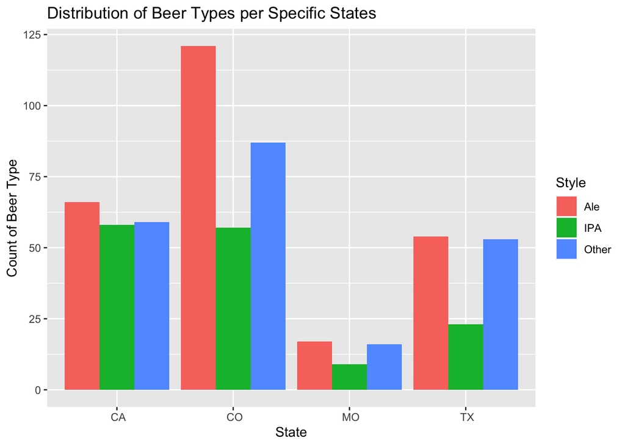

```r
## ^Note American Beer Styles with Frequency Over 30

## Plots Comparing IPA vs Ale in Top-3 States & MO
Oktoberfest3 = Oktoberfest %>%
  mutate(Style = if_else(str_detect(Oktoberfest$Style, "IPA"), "IPA", if_else(str_detect(Oktoberfest$Style, "Ale"), "Ale", "Other"))) %>%
  filter(State == " MO" | State == " TX" | State == " CO" | State == " CA") %>%
  filter(!is.na(Style)) %>%
  select(State, Style)

Oktoberfest3 %>% ggplot(aes(x = State, fill = Style)) +
  geom_bar(position = "dodge") + ggtitle("Distribution of Beer Types per Specific States")+ ylab("Count of Beer Type")
```

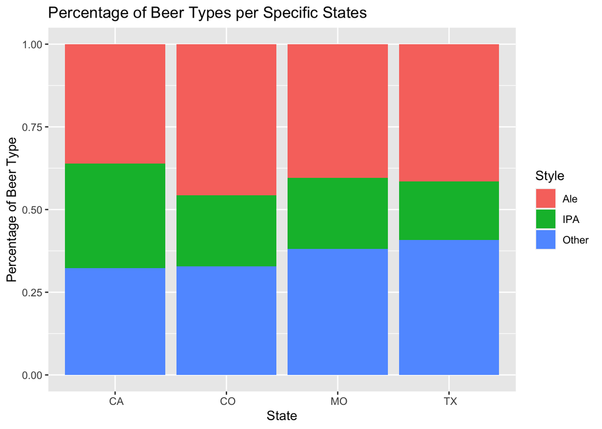

```r
Oktoberfest3 %>% ggplot(aes(x = State, fill = Style)) +
  geom_bar(position = "fill") + ggtitle("Percentage of Beer Types per Specific States") + ylab("Percentage of Beer Type")
```

## American Ale Styles with Frequency over 30

```r
Oktoberfest4 = Oktoberfest %>%
  mutate(Styles = if_else(str_detect(Oktoberfest$Style, "American Amber / Red Ale"), "Red Ale", if_else(str_detect(Oktoberfest$Style, "American Blonde Ale"), "Blonde Ale", if_else(str_detect(Oktoberfest$Style, "American Brown Ale"), "Brown Ale", if_else(str_detect(Oktoberfest$Style, "American Double / Imperial IPA"), "IPA", if_else(str_detect(Oktoberfest$Style, "American IPA"), "IPA", if_else(str_detect(Oktoberfest$Style, "APA"), "APA", if_else(str_detect(Oktoberfest$Style, "American Pale Wheat Ale"), "Pale Wheat Ale", if_else(str_detect(Oktoberfest$Style, "American Porter"), "American Porter", if_else(str_detect(Oktoberfest$Style, "Fruit / Vegetable Beer"), "Fruit / Vegetable Beer", "Other" )))))))))) %>%
  filter(!is.na(ABV)) %>%
  filter(!is.na(IBU)) %>%
  filter(!is.na(Styles)) %>%
  filter(Styles != "Other") %>%
  filter(State == " MO"| State == " TX" | State == " CO" | State == " CA") %>%
  select(State,Styles)
Oktoberfest4$Styles = as.factor(Oktoberfest4$Styles)
levels(Oktoberfest4$Styles)
```

```
## [1] "American Porter"        "APA"                    "Blonde Ale"
## [4] "Brown Ale"              "Fruit / Vegetable Beer" "IPA"
## [7] "Pale Wheat Ale"         "Red Ale"
```

```r
table(Oktoberfest4$Styles)
```

```
##
##        American Porter                    APA             Blonde Ale
##                      6                     47                     19
##              Brown Ale Fruit / Vegetable Beer                    IPA
##                      7                      8                    106
##         Pale Wheat Ale                Red Ale
##                     12                     24
```

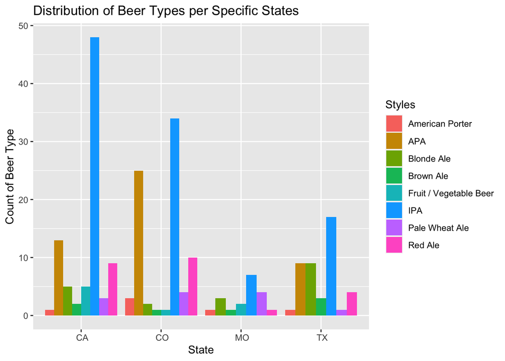

```r
## Plots for Top-4 States
Oktoberfest4 %>% ggplot(aes(x = State, fill = Styles)) +
  geom_bar(position = "dodge") + ggtitle("Distribution of Beer Types per Specific States")+ ylab("Count of Beer Type")
```

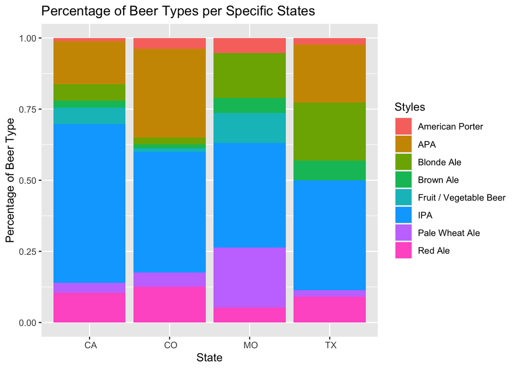

```r
Oktoberfest4 %>% ggplot(aes(x = State, fill = Styles)) +
  geom_bar(position = "fill") + ggtitle("Percentage of Beer Types per Specific States") + ylab("Percentage of Beer Type")
```